# ds202_hw5

# 5.Plot volume sold by day (use a scatterplot of volume by day and facet by month). Discover any trend with the help of geom_smooth. Describe any patterns.

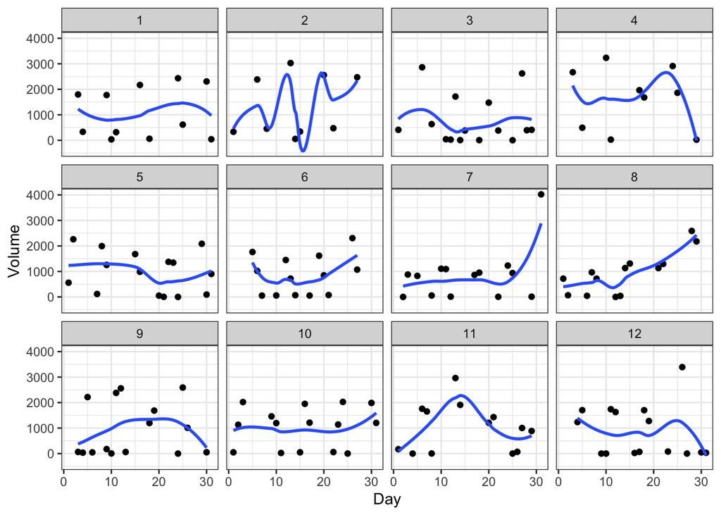

```r
ames4 %>%
  ggplot(aes(x=Day, y=Volume))+geom_point()+geom_smooth(se = FALSE)+facet_wrap(~Month)+theme_bw()
```

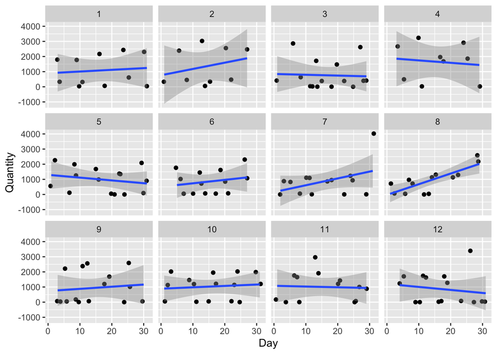

```r
amesF %>% ggplot(aes(x=Day,y=Quantity))+geom_jitter()+geom_smooth(method="lm")+facet_wrap(~Month)
```

# 6.Find the dates for ISU football home games in Fall 2019. Can you see a pattern?

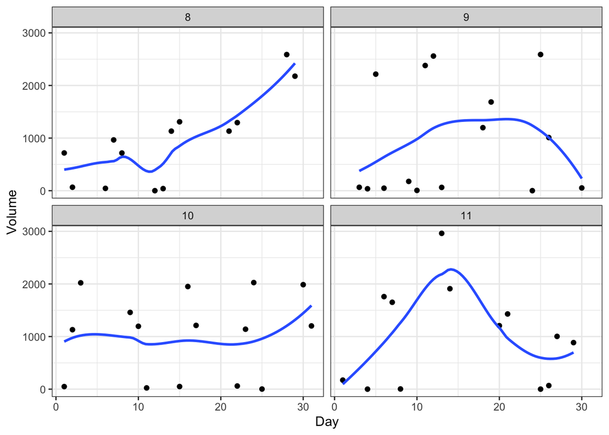

```r
ames4 %>%
  filter(Month %in% c(8,9,10,11)) %>%
  ggplot(aes(x=Day, y=Volume))+geom_point()+geom_smooth(se = FALSE)+facet_wrap(~Month)+theme_bw()
```

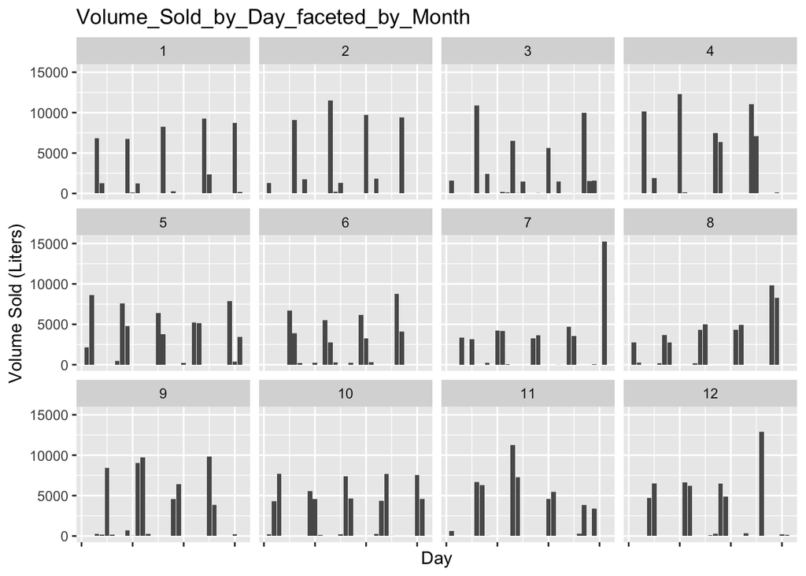

```r
ggplot(ames3, aes(x=Day,y=`Volume Sold (Liters)`)) +
  geom_col() +
  facet_wrap(vars(Month)) +
  theme(axis.text.x = element_blank()) +
  labs(title = "Volume_Sold_by_Day_faceted_by_Month")
```

The dates for the football season were 8/31, 9/14, 9/21, 9/28, 10/5, 10/12, 10/19, 10/26, 11/9, 11/16, 11/23, and 11/30.There are always big increases in sales the few days prior to home football games.